# tp_serie_temporelle

2025-10-02

## Contexte du TP

```
## # A tibble: 6 × 2
##   mois       T_moy
##   <date>     <dbl>
## 1 1990-01-01  2.46
## 2 1990-02-01 10
## 3 1990-03-01  9.25
## 4 1990-04-01  9.65
## 5 1990-05-01 18.2
## 6 1990-06-01 18.6
```

Statistiques descriptives de la série temporelle

| Statistique | Valeur |
| --- | --- |
| Moyenne | 13.175 |
| Médiane | 12.634 |
| Variance | 47.203 |
| Skewness (asymétrie) | 0.044 |
| Kurtosis (aplatissement) | 1.788 |

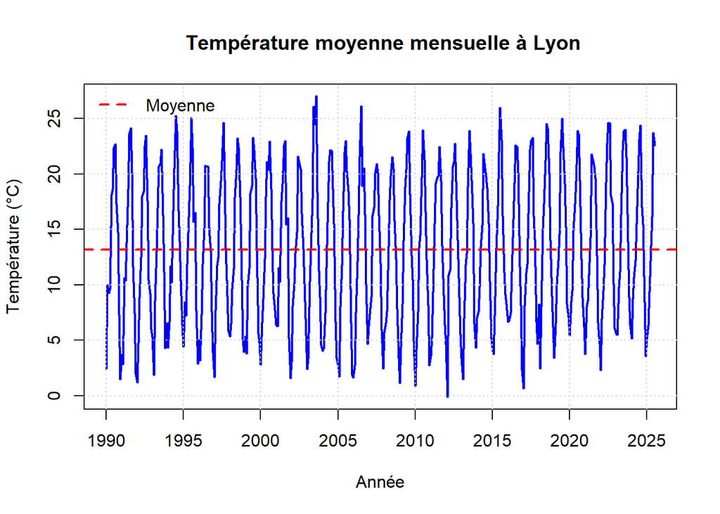

#La série temporelle présente une moyenne d’environ 13,2°C et une médiane proche (12,6°C), ce qui suggère une distribution globalement symétrique. #La variance (47,2) indique une dispersion modérée des valeurs autour de la moyenne, avec un écart-type d’environ 7°C. #Le skewness proche de zéro (0,04) confirme l’absence d’asymétrie marquée, #tandis que le kurtosis inférieur à 3 (1,79) traduit une distribution plus aplatie que la normale, avec moins de valeurs extrêmes.

#La série présente une forte saisonnalité annuelle (été chaud, hiver froid), avec une amplitude assez stable (~20°C). #On peut suspecter une tendance légèrement haussière des températures maximales récentes, mais ce n’est pas flagrant visuellement.

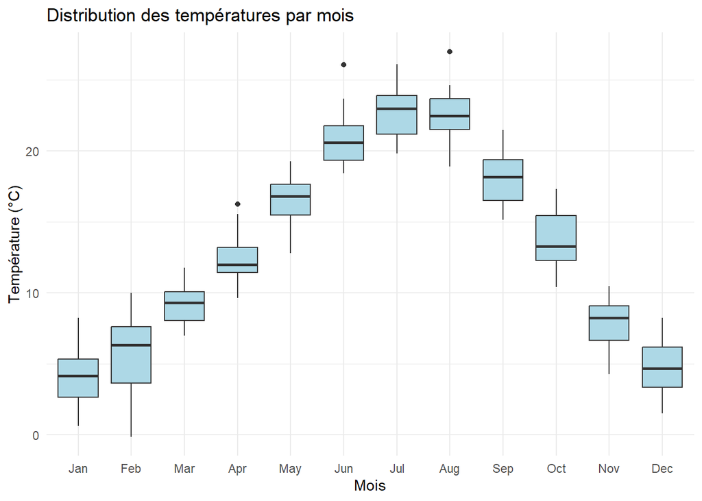

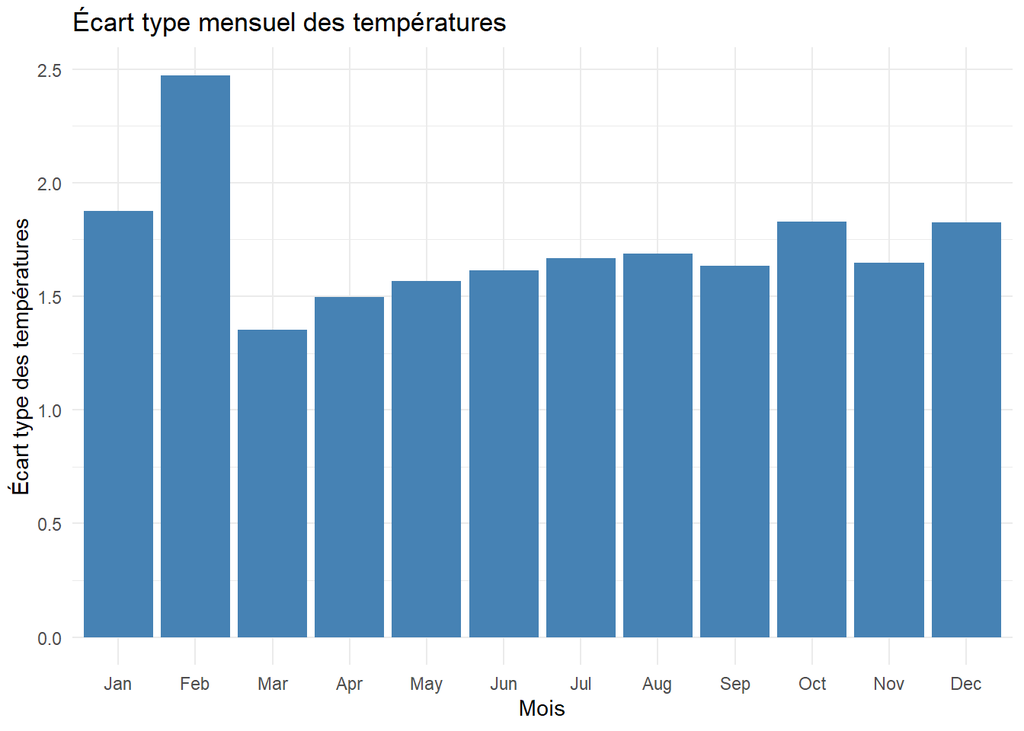

#La volatilité dépend du mois étudié. Sur le graphe on voit l’hétéroscélasticité des températures, notament un écart type plus important pour le mois de Janvier avec un écart type de 1.876471°C ou Février avec 2.472963°c contre un écart type de température plus faible pour les mois de Mars ou Avril (1.350898°C resp. 1.497665°C) par exemple.

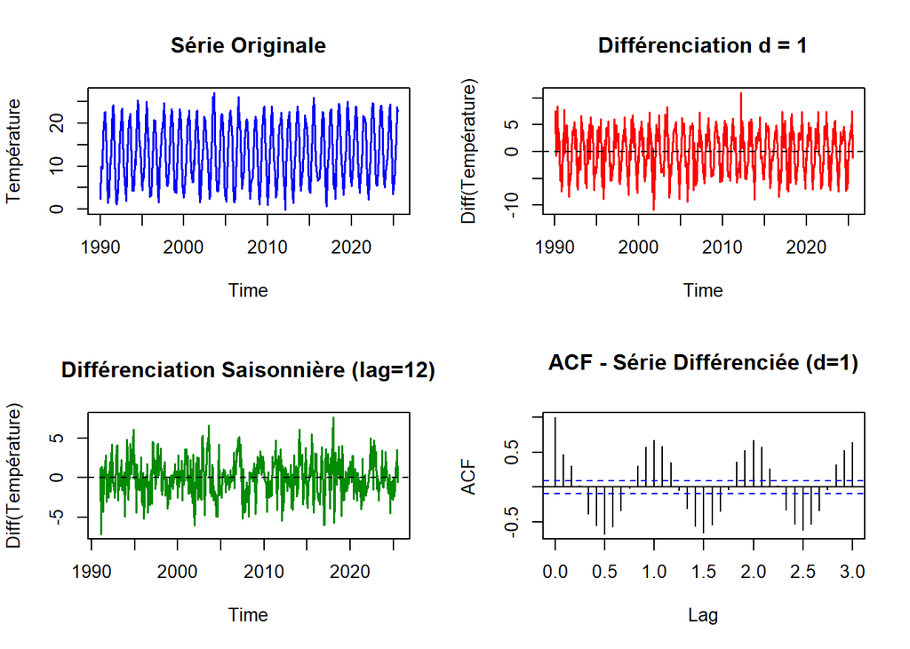

```
##
## Test ADF après différenciation (d=1) :
```

```
## p-value : 0.01
```

La différentiationd’ordre 1 n’est pas satisfaisante. Regardons avec lag 12.

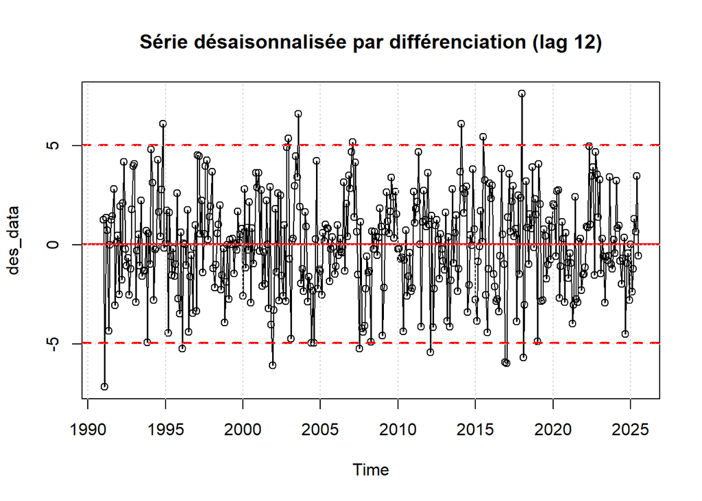

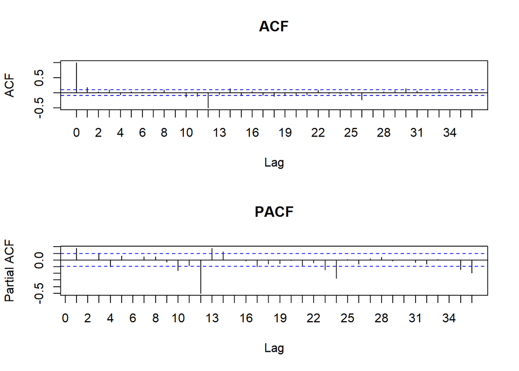

```
##
##  Augmented Dickey-Fuller Test
##
## data:  des_data
## Dickey-Fuller = -6.0214, Lag order = 7, p-value = 0.01
## alternative hypothesis: stationary
```

```
## INTERPRÉTATION DU TEST ADF :
## -----------------------------
## - H0 : la série n'est pas Stationnaire
## - p-value < 0.05 → On REJETTE H0
## - ✓ La série est stationnaire.
```

```
##
## Test KPSS sur la série brute :
```

```
## Statistique KPSS : 0.0148
```

```
## p-value : 0.1
```

```
## ✓ La série est STATIONNAIRE (p ≥ 0.05)
```

```
##    type ordre      AIC      BIC
## 1    AR     1 1927.719 1939.804
## 2    AR     2 1929.719 1945.832
## 3    AR     3 1927.366 1947.507
## 4    AR     4 1924.823 1948.993
## 5    AR     5 1925.133 1953.331
## 6    MA     1 1927.547 1939.632
## 7    MA     2 1929.420 1945.533
## 8    MA     3 1923.309 1943.450
## 9    MA     4 1921.099 1945.268
## 10   MA     5 1920.221 1948.419
```

```
## Meilleur modèle selon AIC: MA ( 5 )
##  Meilleur modèle selon BIC: MA ( 1 )
##  Meilleur modèle AR selon AIC: AR ( 4 )
##  Meilleur modèle AR selon BIC: AR ( 1 )
##  Meilleur modèle MA selon AIC: MA ( 5 )
##  Meilleur modèle MA selon BIC: MA ( 1 )
```

Effectivement, les modèles avec plus de paramètres ont un meilleur AIC mais c’est dû à un “sur-apprentissage” qui est mis en évidence par la mesure du BIC qui met les modèles AR(1) et MA(1) en avant. On comprend bien intuitivement que la température moyenne pour le mois de juin par exemple dépend peu de la température de la même année en Janvier.

```
##
## Meilleur modèle ARMA selon AIC: ARMA( 5 0 5 )
##  Meilleur modèle ARMA selon BIC: ARMA( 5 0 5 )
```

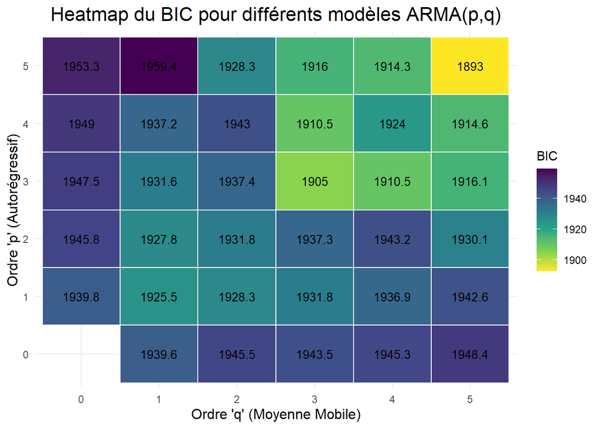

Partie 2 : Modélisation et analyse

```
## [1] 1924.823
```

```
## [1] 1844.665
```

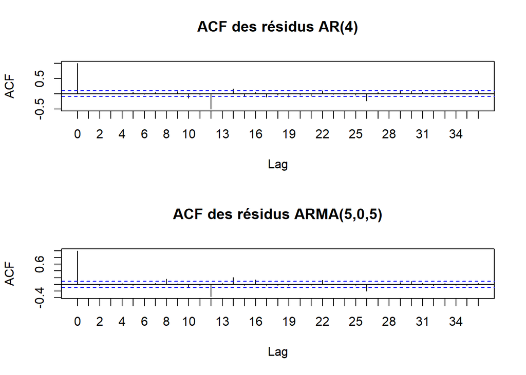

```
##
##  Box-Ljung test
##
## data:  res_AR
## X-squared = 146.83, df = 20, p-value < 2.2e-16
```

```
##
##  Box-Ljung test
##
## data:  res_ARMA
## X-squared = 101.65, df = 20, p-value = 6.38e-13
```

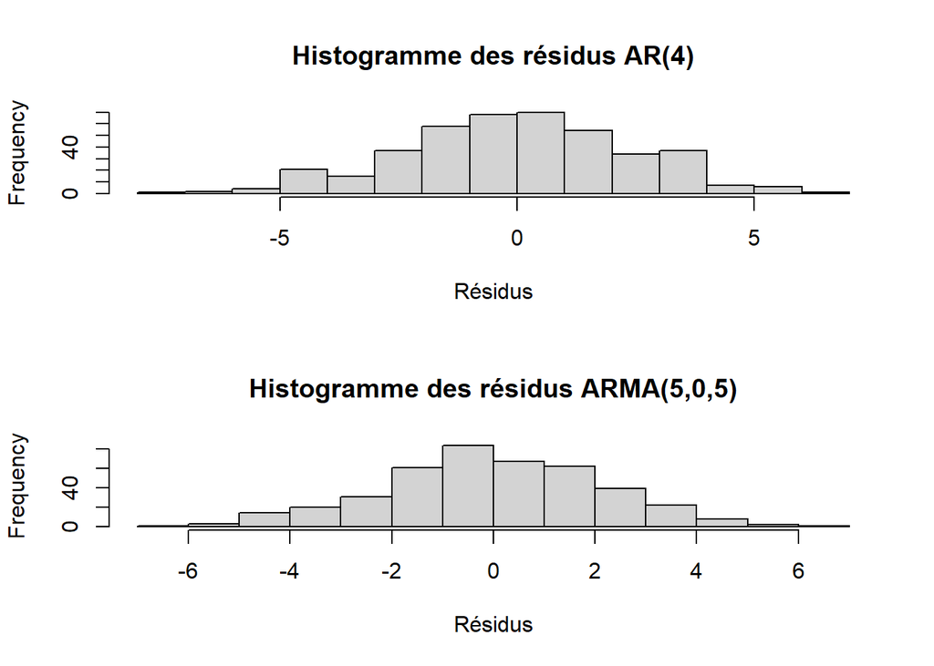

Les résidus ne peuvent pas être considéré comme des bruits blancs au vu du test de Ljung-Box avec des p_value égal à des 0 machine. On le voit avec le plot des ACF des 2 modèles qui montrent une corrélation au lag 12 (Le mois de l’année précedente).

```
## [1] 1927.719
```

```
## [1] 1927.547
```

[figure not shown]

```
##
##  Box-Ljung test
##
## data:  res_AR_1
## X-squared = 160.71, df = 20, p-value < 2.2e-16
```

```
##
##  Box-Ljung test
##
## data:  res_MA_1
## X-squared = 161.26, df = 20, p-value < 2.2e-16
```

[figure not shown]

Pas non plus de Ljung-Box

```
## Sélection automatique du meilleur modèle ARIMA...
```

[output not shown]

[output cut: 142 more lines]

```
##  ARIMA(3,0,2)            with non-zero mean : 1909.52
##  ARIMA(4,0,0)            with zero mean     : 1923.008
##  ARIMA(4,0,0)            with non-zero mean : 1925.029
##  ARIMA(4,0,0)(0,0,1)[12] with zero mean     : Inf
##  ARIMA(4,0,0)(0,0,1)[12] with non-zero mean : Inf
##  ARIMA(4,0,0)(1,0,0)[12] with zero mean     : 1799.596
##  ARIMA(4,0,0)(1,0,0)[12] with non-zero mean : 1801.487
##  ARIMA(4,0,1)            with zero mean     : 1907.284
##  ARIMA(4,0,1)            with non-zero mean : 1909.325
##  ARIMA(5,0,0)            with zero mean     : 1923.37
##  ARIMA(5,0,0)            with non-zero mean : 1925.408
##
##
##
##  Best model: ARIMA(1,0,1)(2,0,1)[12] with zero mean
```

```
## MEILLEUR MODÈLE SÉLECTIONNÉ
```

```
## Series: des_data
## ARIMA(1,0,1)(2,0,1)[12] with zero mean
##
## Coefficients:
##           ar1     ma1     sar1     sar2     sma1
##       -0.5596  0.7149  -0.0828  -0.0461  -0.8856
## s.e.   0.1554  0.1313   0.0615   0.0585   0.0441
##
## sigma^2 = 3.093:  log likelihood = -831.23
## AIC=1674.46   AICc=1674.67   BIC=1698.63
##
## Training set error measures:
##                     ME     RMSE      MAE MPE MAPE      MASE       ACF1
## Training set 0.1965763 1.748182 1.428169 Inf  Inf 0.4074517 0.01816156
```

Comparaison des Modèles ARIMA

| Modèle | AIC | BIC | AICc | LogLik |
| --- | --- | --- | --- | --- |
| Auto ARIMA | 1674.46 | 1698.63 | 1674.67 | -831.23 |
| ARIMA(1,1,2)(2,1,1)[12] | 1762.22 | 1790.22 | 1762.51 | -874.11 |
| ARIMA(1,1,2)(2,1,1)[12] | 1762.22 | 1790.22 | 1762.51 | -874.11 |
| ARIMA(2,1,2)(1,1,1)[12] | 1808.50 | 1836.49 | 1808.79 | -897.25 |
| ARIMA(1,1,1)(1,1,1)[12] | 1815.60 | 1835.59 | 1815.75 | -902.80 |

```
##
## ✓ Le meilleur modèle selon AICc est : Auto ARIMA
```

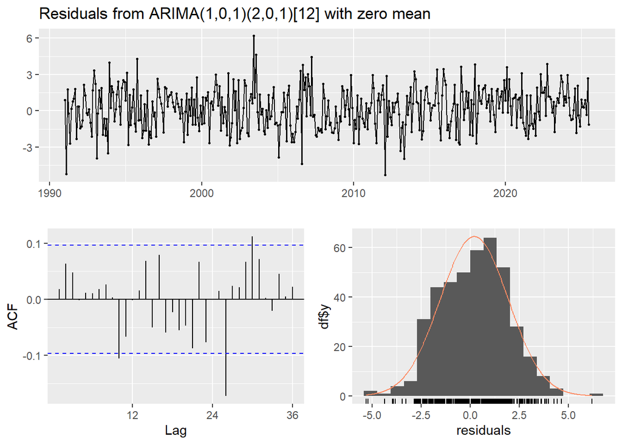

```
##
##  Ljung-Box test
##
## data:  Residuals from ARIMA(1,0,1)(2,0,1)[12] with zero mean
## Q* = 27.791, df = 19, p-value = 0.08753
##
## Model df: 5.   Total lags used: 24
```

```
##
## --- Tests Complémentaires sur les Résidus ---
```

```
## Test de Ljung-Box (H0 : pas d'autocorrélation) :
```

```
##   p-value = 0.4642
```

```
##   ✓ Les résidus sont un bruit blanc (p > 0.05)
```

```
## Test de Shapiro-Wilk (H0 : normalité) :
```

```
##   p-value = 0.3045
```

```
##   ✓ Les résidus suivent une loi normale (p > 0.05)
```

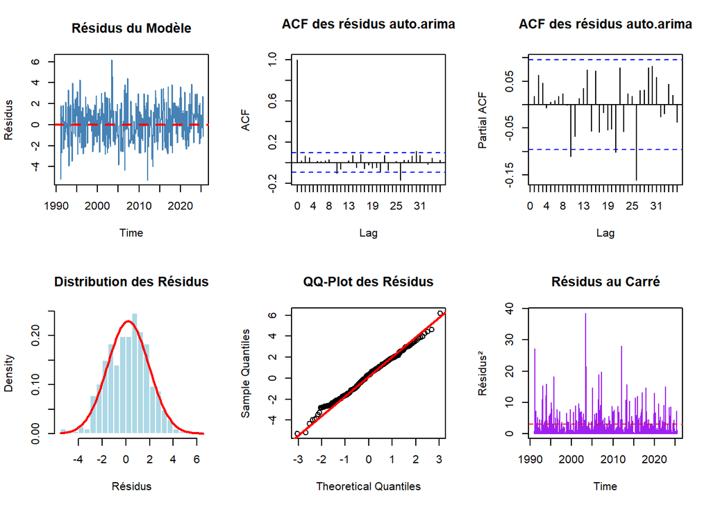

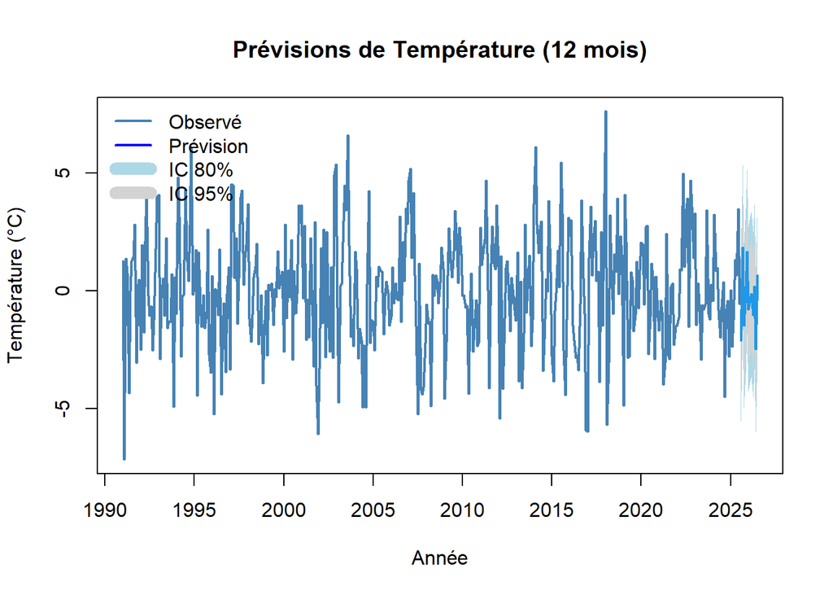

Prévisions Mensuelles (12 prochains mois)

| Mois | Prévision (°C) | IC Inf 95% | IC Sup 95% |
| --- | --- | --- | --- |
| 1 | -2.11 | -5.56 | 1.34 |
| 2 | 1.84 | -1.65 | 5.33 |
| 3 | -1.48 | -4.98 | 2.02 |
| 4 | 0.00 | -3.50 | 3.51 |
| 5 | 1.65 | -1.85 | 5.16 |
| 6 | -0.79 | -4.30 | 2.72 |
| 7 | -0.36 | -3.87 | 3.15 |
| 8 | -0.14 | -3.65 | 3.36 |
| 9 | -1.02 | -4.52 | 2.49 |
| 10 | 0.19 | -3.32 | 3.69 |
| 11 | -2.49 | -5.99 | 1.02 |
| 12 | 0.65 | -2.85 | 4.16 |

[figure not shown]